# Part II - Bike Sharing System Data Analysis

## by Dalal Bin Gheshiyan

## Investigation Overview

In this investigation, I wanted to look at what age people usually ride a bike, and if that can give a prediction about the duration of a trip. also considering gender and his/her type of subscription does it changes? furthermore, what most popular places people ride a bike?

## Dataset Overview

The data consists of information regarding 183412 rides made in a bike-sharing system covering the greater San Francisco Bay area, including 16 features about the area, rider and bike. around 8265 records were removed during the analysis as they consist of missing or null values.

## 1. What is the most popular age to ride a bike?

Mostly, riders' ages range between their 20s to 40s, however, there is a people who ride until their 90s.

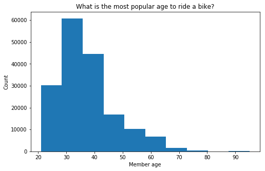

## 2. How long does the trip take?

Minimum duration for a trip is 60 sec and maximum 25600. with mostly 500 seconds for a trip.

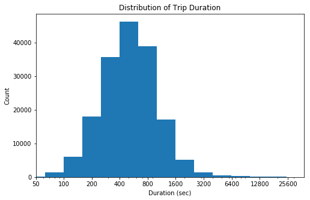

## 3.What is the most popular places to start and end a bike trip?

As dataset has large numbers for places, I just toke the top 10.

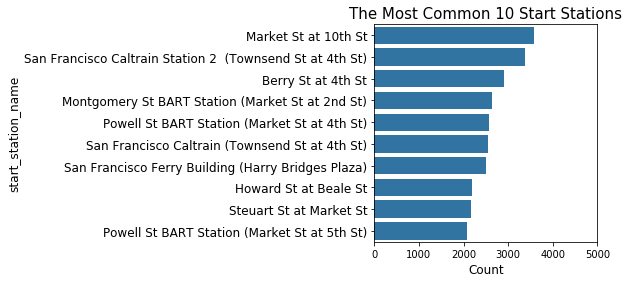

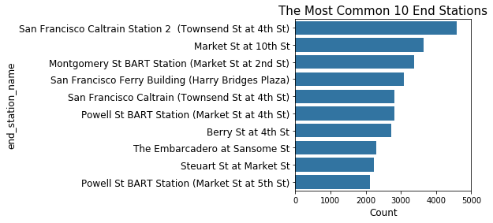

## 4. What is the realtion between Duration, Gender and User type?

Female has longer trip whether they are subscribers or customers, and customers for both male and female is longer than the subscriber members trips.

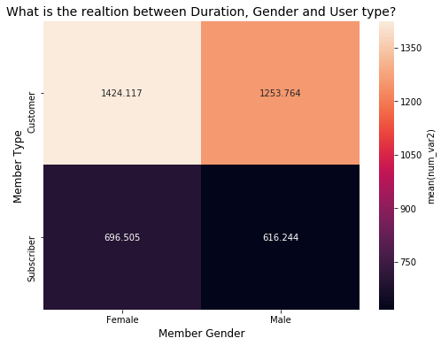